# PeMS: regional flow and CHP starts on 2026-06-16

## Sources and measurements

The example contains 24 hourly frames on 2026-06-16. Los Angeles Area uses D07, D08 and D12 records; San Francisco Bay Area uses D04 records. Flow and CHP starts are shown separately for each region.

Los Angeles hourly station values come from `flow_2026_06.binz`. D04 uses `d04_text_station_5min_2026_06_16.txt.gz`: twelve complete five-minute counts form each station-hour total. Display-link flow is the mean of available endpoint station values, in vehicles/hour.

The selected records contain 1,019 CHP starts: 700 in Los Angeles and 319 in D04. Each marker represents a reported start in the selected hour. End times are unavailable, so the markers do not establish event duration or an effect on traffic.

## Data preparation

`prepare.R` aligns source stations with the supplied links, forms hourly values and assigns CHP starts to their reported hour and region. The bundled `data/source.rds` records become the common road-flow and event fields in `data/input.rds`.

```r
library(bdynets)
source("prepare.R")
prepared_file <- prepare_example(".")
x <- read_traffic(prepared_file)
input <- readRDS(prepared_file)
x$basemap <- traffic_basemap(x,cache_dir=file.path("data","basemap-cache"))
x$provenance$basemap <- x$basemap$provenance
runtime_context <- x$basemap
index <- match(params$time_label,sub("^.* ","",x$time_labels))
stopifnot(!is.na(index))
```

The map starts at 2026-06-16 08:00 and covers 60 minutes. The default 08:00 is a demonstration selection, not a maximum-based selection. Numeric seconds and displayed labels retain the supplied source clock; they do not establish a UTC offset.

```r
knitr::kable(data.frame(Region=x$regions,
  Roads=vapply(x$regions,function(z)sum(x$roads$region==z),integer(1)),
  Whole_day_starts=vapply(x$regions,function(z)sum(x$events$region==z),integer(1))),
  caption="Whole-day regional scope")
```

Whole-day regional scope

|  | Region | Roads | Whole_day_starts |
| --- | --- | --- | --- |
| Los Angeles Area | Los Angeles Area | 4435 | 700 |
| San Francisco Bay Area | San Francisco Bay Area | 2203 | 319 |

```r
knitr::kable(head(input$flow),caption="Actual prepared road-hour records")
```

Actual prepared road-hour records

| road_id | time | flow |
| --- | --- | --- |
| 0 | 1781568000 | 360.0 |
| 1 | 1781568000 | 1726.0 |
| 2 | 1781568000 | 1550.5 |
| 3 | 1781568000 | 1713.0 |
| 4 | 1781568000 | 930.0 |
| 5 | 1781568000 | 1384.5 |

```r
knitr::kable(head(input$events[c("id","time_label","lon","lat","category","region")]),
  caption="Actual prepared event records")
```

Actual prepared event records

| id | time_label | lon | lat | category | region |
| --- | --- | --- | --- | --- | --- |
| 23633026 | 2026-06-16 00:04:00 | -118.1121 | 34.50938 | Driving risk | Los Angeles Area |
| 23633032 | 2026-06-16 00:14:00 | -116.3546 | 33.78583 | Collision | Los Angeles Area |
| 23633029 | 2026-06-16 00:18:00 | -117.8395 | 34.06887 | Road hazard | Los Angeles Area |
| 23633034 | 2026-06-16 00:23:00 | -117.8241 | 34.12063 | Road hazard | Los Angeles Area |
| 23633038 | 2026-06-16 00:24:00 | -118.2073 | 33.80432 | Fire | Los Angeles Area |
| 23633040 | 2026-06-16 00:29:00 | -118.0042 | 34.05426 | Collision | Los Angeles Area |

| Common field | Meaning |
| --- | --- |
| road_id, geometry | Unique display link and travel-ordered longitude/latitude vertices |
| from_station, to_station | Endpoint source station identifiers |
| time, flow | Source-clock hour start and endpoint-mean hourly rate |
| id, time, lon, lat | Unique report ID, reported start and coordinates |
| category, description | Source-type classification and retained source text |
| region | Explicit geographic selection label |

Both regions use the same object, plot method and global log1p thresholds. Their central-area views do not restrict regional statistics. Red diamonds mark starts in the selected hour. Geographic overlap alone does not establish a relationship between a report and a road measurement.

## Los Angeles Area

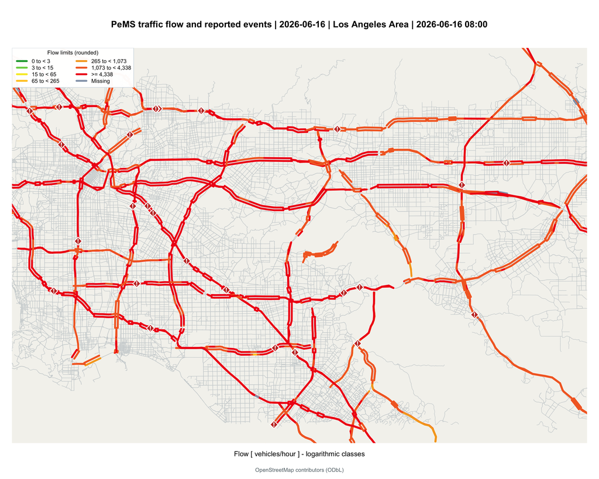

Los Angeles Area: road flow and CHP reported starts in the selected hour. Colors use the same full-day, two-region thresholds.

```r
region <- "Los Angeles Area"
plot(x,index=index,region=region)
```

```r
coverage <- traffic_coverage(x,region=region)
knitr::kable(data.frame(
  Statistic=c("Roads","Road-hour cells","Observed cells","Missing cells","Zero cells","Whole-day starts"),
  Value=unlist(coverage[c("roads","road_time_cells","observed","missing","zero","event_starts")],use.names=FALSE)),
  caption="Whole-day coverage")
```

Whole-day coverage

| Statistic | Value |
| --- | --- |
| Roads | 4435 |
| Road-hour cells | 106440 |
| Observed cells | 105096 |
| Missing cells | 1344 |
| Zero cells | 20 |
| Whole-day starts | 700 |

```r
selected <- traffic_summary(x,index=index,region=region)
knitr::kable(selected[c("time","available","missing","zero","events")],
  caption="Selected-hour observations and starts")
```

Selected-hour observations and starts

| time | available | missing | zero | events |
| --- | --- | --- | --- | --- |
| 2026-06-16 08:00 | 4379 | 56 | 0 | 36 |

```r
knitr::kable(selected[c("minimum","median","mean","p95","maximum")],
  digits=2,caption="Selected-hour distribution [vehicles/hour]")
```

Selected-hour distribution [vehicles/hour]

| minimum | median | mean | p95 | maximum |
| --- | --- | --- | --- | --- |
| 204 | 4464.5 | 4427.63 | 7412 | 16727 |

At 2026-06-16 08:00, mean available-link flow is 4,427.63 vehicles/hour, with 36 reported starts in this hour. The whole-day total is 700 starts. These statistics have different time scopes. The 56 unavailable links in each hour produce 1,344 missing road-hour cells. The hourly export does not establish complete five-minute coverage for every underlying Los Angeles station.

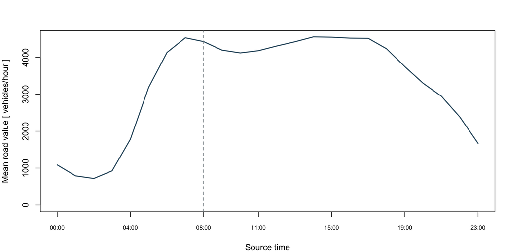

Regional mean available-link flow by hour. The dashed line marks the selected map hour.

```r
trend <- traffic_trend(x,region=region,method="mean")
plot(trend,metric="mean",index=index)
```

```r
flow_peak <- which.max(trend$mean)
```

The greatest regional mean is 4,555.08 vehicles/hour at 2026-06-16 14:00. Missing link values are excluded from the mean. This curve does not measure speed or regional vehicle totals.

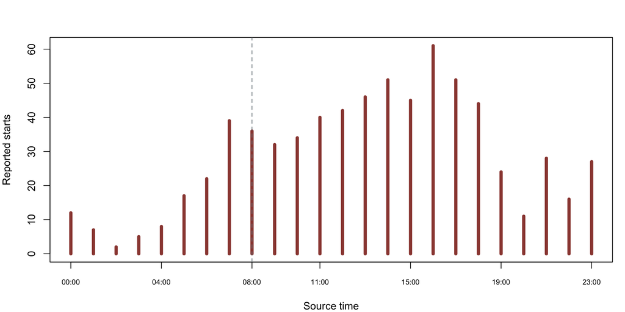

Reported event starts per source-clock hour. The dashed line marks the selected map hour; durations are not inferred.

```r
plot(trend,metric="events",index=index)
```

```r
event_peak <- which.max(trend$events)
```

The largest hourly count is 61 starts at 2026-06-16 16:00. A coincident change in flow would not by itself establish an event effect.

## San Francisco Bay Area

[figure not shown]

San Francisco Bay Area: road flow and CHP reported starts in the selected hour. Colors use the same full-day, two-region thresholds.

```r
region <- "San Francisco Bay Area"
plot(x,index=index,region=region)
```

```r
coverage <- traffic_coverage(x,region=region)
knitr::kable(data.frame(
  Statistic=c("Roads","Road-hour cells","Observed cells","Missing cells","Zero cells","Whole-day starts"),
  Value=unlist(coverage[c("roads","road_time_cells","observed","missing","zero","event_starts")],use.names=FALSE)),
  caption="Whole-day coverage")
```

Whole-day coverage

| Statistic | Value |
| --- | --- |
| Roads | 2203 |
| Road-hour cells | 52872 |
| Observed cells | 52872 |
| Missing cells | 0 |
| Zero cells | 40 |
| Whole-day starts | 319 |

```r
selected <- traffic_summary(x,index=index,region=region)
knitr::kable(selected[c("time","available","missing","zero","events")],
  caption="Selected-hour observations and starts")
```

Selected-hour observations and starts

| time | available | missing | zero | events |
| --- | --- | --- | --- | --- |
| 2026-06-16 08:00 | 2203 | 0 | 2 | 18 |

```r
knitr::kable(selected[c("minimum","median","mean","p95","maximum")],
  digits=2,caption="Selected-hour distribution [vehicles/hour]")
```

Selected-hour distribution [vehicles/hour]

| minimum | median | mean | p95 | maximum |
| --- | --- | --- | --- | --- |
| 0 | 4228 | 4182.51 | 6971.75 | 9471 |

At 2026-06-16 08:00, mean available-link flow is 4,182.51 vehicles/hour, with 18 reported starts in this hour. The whole-day total is 319 starts. These statistics have different time scopes. All 52,872 D04 road-hour values are present. The source has 2,291 mainline stations; 400665, 406767 and 418817 lack matched geometry and are excluded. The 2,288 retained stations have complete five-minute timestamps. Detector imputation may still be present. Six event summaries lack detail messages and remain included.

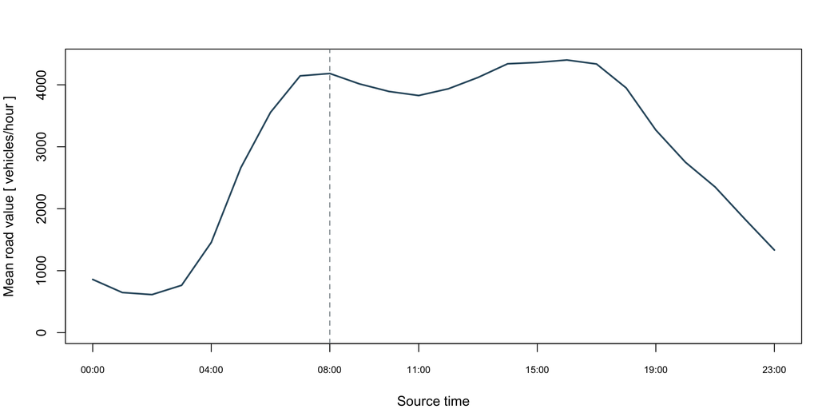

Regional mean available-link flow by hour. The dashed line marks the selected map hour.

```r
trend <- traffic_trend(x,region=region,method="mean")
plot(trend,metric="mean",index=index)
```

```r
flow_peak <- which.max(trend$mean)
```

The greatest regional mean is 4,400.41 vehicles/hour at 2026-06-16 16:00. Missing link values are excluded from the mean. This curve does not measure speed or regional vehicle totals.

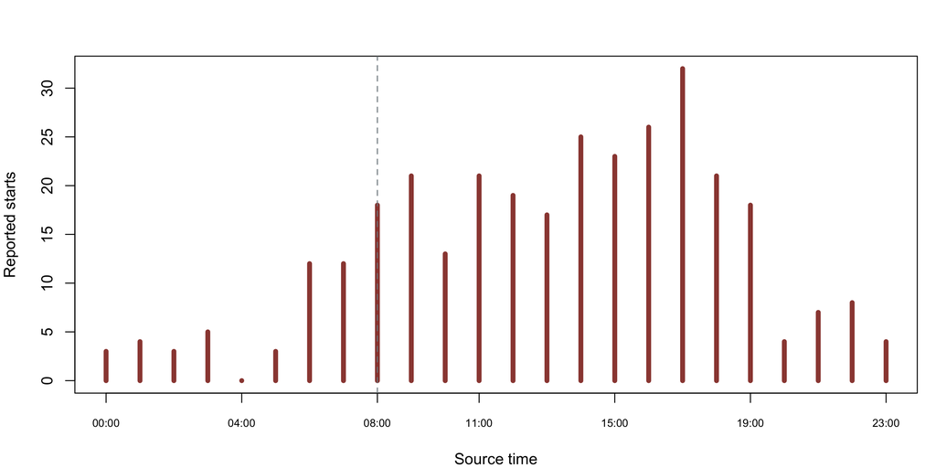

Reported event starts per source-clock hour. The dashed line marks the selected map hour; durations are not inferred.

```r
plot(trend,metric="events",index=index)
```

```r
event_peak <- which.max(trend$events)
```

The largest hourly count is 32 starts at 2026-06-16 17:00. A coincident change in flow would not by itself establish an event effect.

## Figure and data export

`traffic_export()` writes maps, trend figures and the selected data and summary tables for the same input and interval.

```r
if(params$export) {
  label <- gsub("[^[:alnum:]_-]+","-",x$time_labels[index])
  for(region in x$regions) {
    name <- gsub(" ","-",tolower(region))
    traffic_export(x,file.path(params$export_dir,paste(name,label,sep="-")),
      index=index,region=region,
      input_files=c(source="data/source.rds",prepared="data/input.rds"))
  }
}
```

Map data © [OpenStreetMap contributors](https://www.openstreetmap.org/copyright).